# Praca domowa 2

Mikołaj Bójski

## Dane

Dane wykorzystane w Pracy domowej 2 opisują wycenę nieruchmości. Każda obserwacja jest pewną nieruchmością, która posiada informacje takie jak powierzchnia, liczba pokoi, liczba łazienek i wiele więcj. Opis wszystkich kolumn w pliku `README.md`.

## Zadanie 1

Jak wygląda rozkład ceny nieruchomości w poszczególnych kodach pocztowych na przestrzeni lat? Rozważamy kody pocztowe, które mają więcej niż 280 posiadłości.

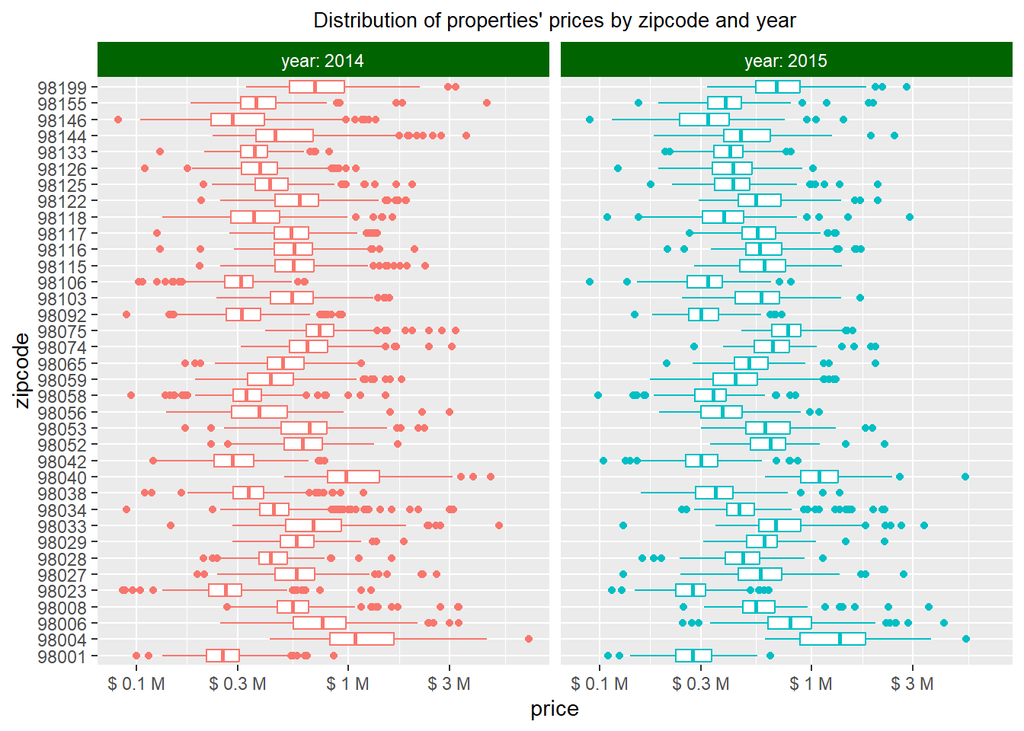

```r
# Tu umieść kod do wygenerowania odpowiedzi do zadania.
temp1 <- unlist(df |>
  group_by(zipcode) |>
  summarise(n = n()) |>
  filter(n > 280) |>
  select(zipcode))

zad1 <- df |>
 select(zipcode, id, date, price) |>
  filter(zipcode %in% temp1) |>
  mutate(year = stri_sub(date, 1, 4), zipcode = as.factor(zipcode))

ggplot(zad1, aes(y = price, x = zipcode, color = year)) +
    geom_boxplot() +
    facet_wrap(year~., labeller = "label_both") +
  scale_y_log10(labels= (\(x) paste("$",as.character(x/1e6),"M"))) +
  labs(title = "Distribution of properties' prices by zipcode and year") +
  theme(legend.position = 'none', plot.title = element_text(hjust = 0.5, size = 10),
        strip.text = element_text(colour = 'white'), strip.background = element_rect(fill = "darkgreen")) +
  coord_flip()
```

**Komentarz:** Rozkład cen nieruchomości różni się zależności od kodu pocztowego, wyróżniającymi się przykładami są kody: 98001, 98004, 98023, 98040 czy 98199. W niektórych przypadkach w różnych latach pojawiają się widoczne różnice, co można dostrzec na przykładzie meadiany dla kodu 98004.

## Zadanie 2

Czy jest różnica w rozkładzie ceny nierchomości od powierzchni mieszkalnej uwzględniając podział na nieruchomości z piwnicą i bez?

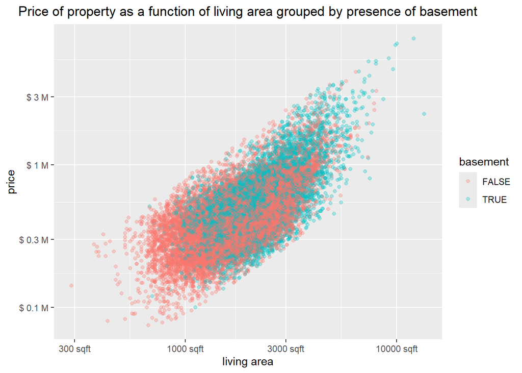

```r
# Tu umieść kod do wygenerowania odpowiedzi do zadania.
zad2 <- df |>
  mutate(basement = ifelse(sqft_basement > 0, TRUE, FALSE), `living area` = sqft_living)

ggplot(zad2, aes(`living area`, price, colour = basement)) +
    geom_point(alpha = 0.3) +
  scale_y_log10(labels= (\(x) paste("$",as.character(x/1e6),"M") )) +
  scale_x_log10(labels= (\(x) paste(as.character(x),"sqft") )) +
  labs(title = "Price of property as a function of living area grouped by presence of basement") +
  theme(plot.title = element_text(hjust = 0.5))
```

**Komentarz:** Tak, z wykresu wynika, że dla danej powierzchnii mieszkalnej rozkład cen nieruchomości z piwnicą jest przesunięty w stronę większych wartości ceny.

## Zadanie 3

Jaka jest zależność pomiędzy jakością wykończenia nieruchomości a liczbą pięter?

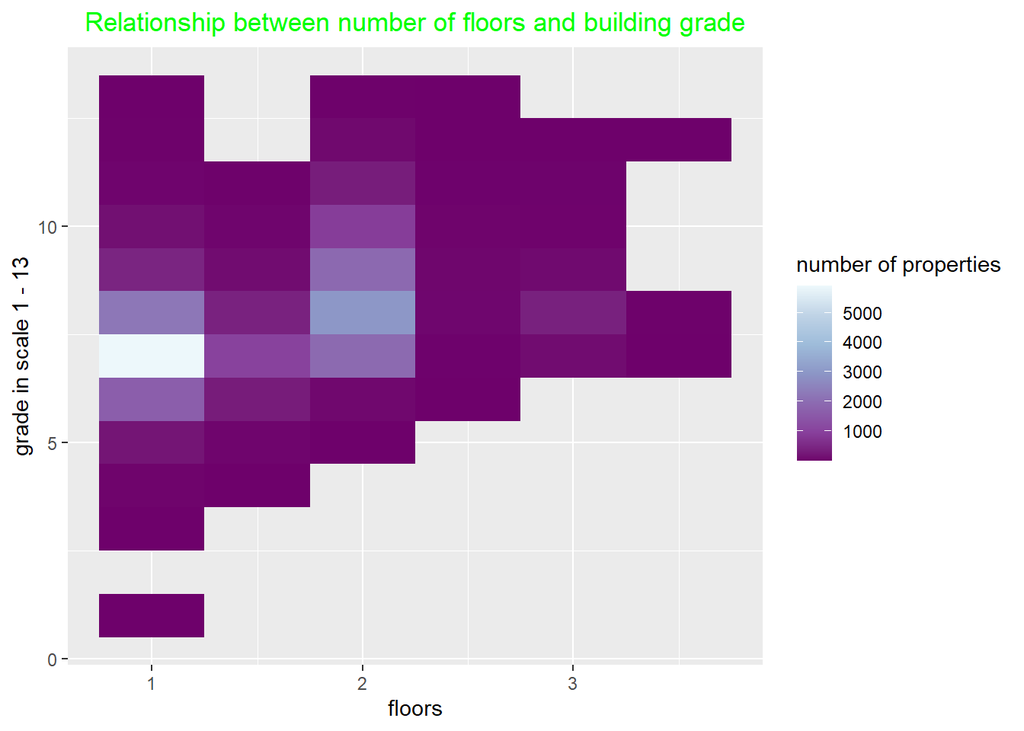

```r
# Tu umieść kod do wygenerowania odpowiedzi do zadania.

zad3 <- df |>
  group_by(floors,grade) |>
  summarise("number of properties" = n())

ggplot(zad3, aes(floors, grade)) +
  geom_tile(aes(fill = `number of properties`)) +
  scale_fill_distiller(palette = "BuPu") +
  labs(title = "Relationship between number of floors and building grade", y = 'grade in scale 1 - 13') +
  theme(plot.title = element_text(hjust = 0.5, color = 'green'))
```

**Komentarz:** Wykres pokazuje, że wzrost liczby pięter z jednego do dwóch przekłada się na niewielki, ale jednak zauważalny, wzrost jakości konstrukcji i wykończenia. Jeśli istnieją inne zależności, które mogłyby być silnie, to nie są one widoczne na powyższym wykresie.

## Zadanie 4

Jaka jest zależność między powierzchnią mieszkalną nieruchomości a powierzchnią gruntu w podziale na liczbę sypialni?

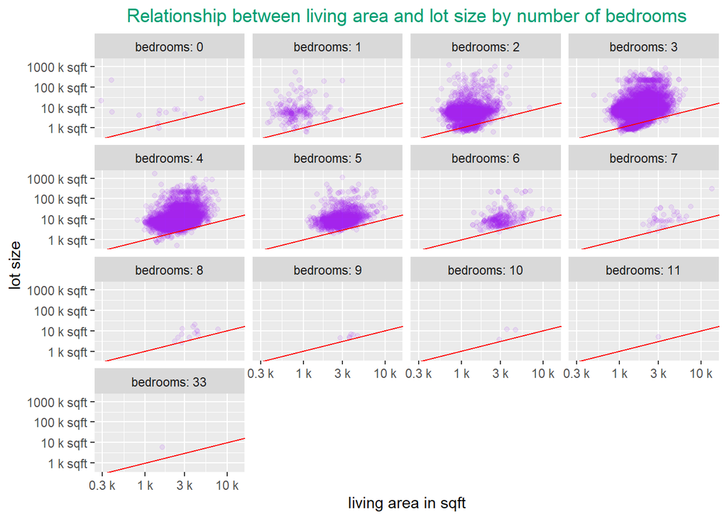

```r
# Tu umieść kod do wygenerowania odpowiedzi do zadania.
zad4 <- df |>
  rename(`living area in sqft` = sqft_living, `lot size` = sqft_lot)

ggplot(zad4, aes(x = `living area in sqft`, y = `lot size`)) +
  geom_point(alpha = 0.1, color = 'purple') +
  geom_abline(color = 'red') +
  facet_wrap(~bedrooms, labeller = "label_both") +
  scale_y_log10(labels= (\(x) paste(as.character(x/1e3),"k sqft") )) +
  scale_x_log10(labels= (\(x) paste(as.character(x/1e3),"k") )) +
  labs(title = "Relationship between living area and lot size by number of bedrooms") +
  theme(plot.title = element_text(hjust = 0.5, color = "#009E73"))
```

**Komentarz:** Dla liczby sypialni w zakresie od 1 do 7 (dla pozostałych jest zbyt mało danych) widać, że im więcej sypialni, tym większa powierchnia mieszkaniowa, co jest oczywistym wnioskiem. Ponadto, z wykresów dla liczby sypialni od 3 do 5 wynika, że, patrząc holistycznie, nieruchomości o większej powierzchnii mieszkaniowej znajdują się na większych działkach.

## Zadanie 5

Rozważmy tylko nieruchomości, które miały remont. W której dekadzie było najwięcej przeprowadzonych remontów? Czy w poszczególnych dekadach jest porównywalny procent nieruchmości dla każdej wartości miary jakości i wykończenia nieruchomości?

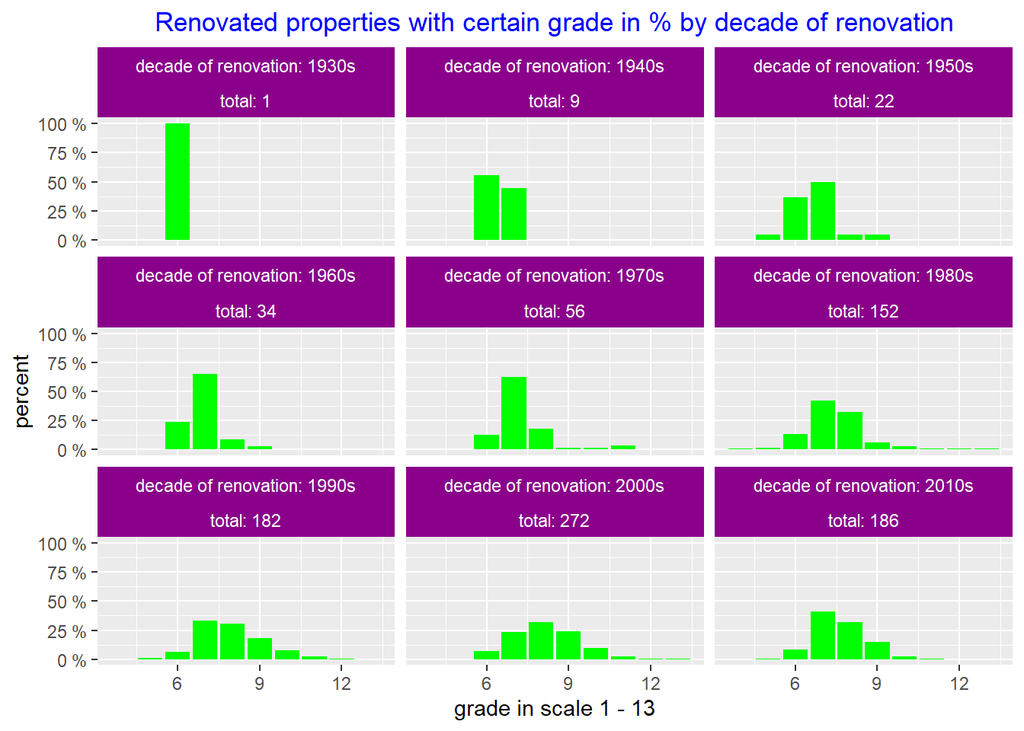

```r
# Tu umieść kod do wygenerowania odpowiedzi do zadania.

zad5 <- df |>
  filter(yr_renovated != 0) |>
  mutate(`decade of renovation` = paste(stri_sub(yr_renovated, 1, 3), "0s", sep = "")) |>
  group_by(`decade of renovation`, grade) |>
  count() |>
  group_by(`decade of renovation`) |>
   mutate(percent = 100* n/sum(n))

temp5 <- zad5 |>
  summarise(total = sum(n))

zad5 <- zad5 |>
  left_join(temp5)

ggplot(zad5, aes(grade, percent)) +
  geom_bar(stat = 'identity', fill = 'green')  +
  facet_wrap(~`decade of renovation`+total, labeller = "label_both") +
  scale_y_continuous(labels= (\(x) paste(as.character(x),"%") )) +
  labs(title = "Renovated properties with certain grade in % by decade of renovation", x = 'grade in scale 1 - 13') +
  theme(plot.title = element_text(hjust = 0.5, color = "blue"),
        strip.text = element_text(colour = 'white'), strip.background = element_rect(fill = "darkmagenta"))
```

**Komentarz:** (Przyjmujemy, że liczba nieruchomości sumuje się do 100% dla każdej dekady osobno.) Najwięcej remontów przeprowadzono w latach 2000. Nie jest porównywalny, czego przykładem są lata 70. i pierwsza dekada XXI wieku.

## Zadanie 6

Jak prezentuje się wartość minimalna, średnia i maksymalna ceny nieruchmości w podziele na rok budowy nieruchomości.

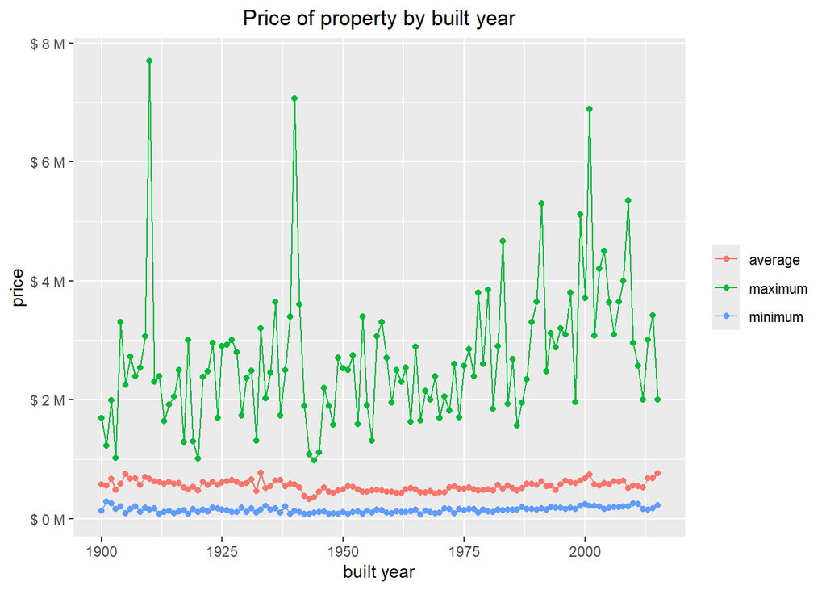

```r
# Tu umieść kod do wygenerowania odpowiedzi do zadania.
zad6 <- df |>
  group_by(`built year` = yr_built) |>
  summarise(minimum = min(price), average = mean(price), maximum = max(price)) |>
  pivot_longer(c(minimum, average, maximum), names_to = 'aggregating_fun', values_to = 'price')

ggplot(zad6, aes(`built year`, price, color = aggregating_fun)) +
  geom_line() +
  geom_point() +
  labs(title="Price of property by built year") +
  scale_y_continuous(labels= (\(x) paste("$",as.character(x/1e6),"M") )) +
  theme(legend.title = element_blank(), plot.title = element_text(hjust = 0.5))
```